# dpa_result_part

DIVYA CHINTALA (A20561001)

2024-07-26

```r
library(ggplot2)
library(caret)
library(dplyr)
library(Hmisc)
library(magrittr)
library(ggpubr)
```

Loading dataset

```r
#setwd("E:/DPA/project/")
data <- read.csv("online_shoppers_intention.csv")


head(data)
```

```
##   Administrative Administrative_Duration Informational Informational_Duration
## 1              0                       0             0                      0
## 2              0                       0             0                      0
## 3              0                       0             0                      0
## 4              0                       0             0                      0
## 5              0                       0             0                      0
## 6              0                       0             0                      0
##   ProductRelated ProductRelated_Duration BounceRates ExitRates PageValues
## 1              1                0.000000  0.20000000 0.2000000          0
## 2              2               64.000000  0.00000000 0.1000000          0
## 3              1                0.000000  0.20000000 0.2000000          0
## 4              2                2.666667  0.05000000 0.1400000          0
## 5             10              627.500000  0.02000000 0.0500000          0
## 6             19              154.216667  0.01578947 0.0245614          0
##   SpecialDay Month OperatingSystems Browser Region TrafficType
## 1          0   Feb                1       1      1           1
## 2          0   Feb                2       2      1           2
## 3          0   Feb                4       1      9           3
## 4          0   Feb                3       2      2           4
## 5          0   Feb                3       3      1           4
## 6          0   Feb                2       2      1           3
##         VisitorType Weekend Revenue
## 1 Returning_Visitor   FALSE   FALSE
## 2 Returning_Visitor   FALSE   FALSE
## 3 Returning_Visitor   FALSE   FALSE
## 4 Returning_Visitor   FALSE   FALSE
## 5 Returning_Visitor    TRUE   FALSE
## 6 Returning_Visitor   FALSE   FALSE
```

Number of duplicate observations

```r
sum(duplicated(data))
```

```
## [1] 125
```

Duplicate observations

```r
data[duplicated(data), ]
```

```
##       Administrative Administrative_Duration Informational
## 159                0                       0             0
## 160                0                       0             0
## 179                0                       0             0
## 419                0                       0             0
## 457                0                       0             0
## 484                0                       0             0
## 513                0                       0             0
## 541                0                       0             0
## 555                0                       0             0
## 590                0                       0             0
## 660                0                       0             0
## 721                0                       0             0
## 775                0                       0             0
## 873                0                       0             0
```

[output cut: 489 more lines]

Check number of observations with NA values

```r
sum(is.na(data))
```

```
## [1] 0
```

Found out that Jan and April months is not present

```r
table(data$Month)
```

```
##
##  Aug  Dec  Feb  Jul June  Mar  May  Nov  Oct  Sep
##  433 1727  184  432  288 1907 3364 2998  549  448
```

“as.factor”, convert month column to factor data type, this is used when the column is categorical attribute with fixed number of categories, in our cases it is months of a year.

“table”, just shows counts of data in each month. Even though “June” is there in data set it is showing count as 0 because it is denoted as “June” instead of 3 letter abbreviation “Jun”

```r
data$Month = as.factor(data$Month)
print(data$Month)
```

[output not shown]

[output cut: 867 more lines]

```r
table(factor(data$Month, levels = month.abb))
```

```
##
##  Jan  Feb  Mar  Apr  May  Jun  Jul  Aug  Sep  Oct  Nov  Dec
##    0  184 1907    0 3364    0  432  433  448  549 2998 1727
```

Changing “June” to 3 character abbreviation “Jun”. data$Month is in factor data type, so we convert it to character to change “June” to “Jun” and again convert back to factor datatype

```r
class(data$Month)
```

```
## [1] "factor"
```

```r
data$Month <- as.character(data$Month)
data$Month[data$Month == "June"] <- "Jun"
data$Month <- as.factor(data$Month)
```

Now we can see “Jun” data set count

```r
table(data$Month)
```

```
##
##  Aug  Dec  Feb  Jul  Jun  Mar  May  Nov  Oct  Sep
##  433 1727  184  432  288 1907 3364 2998  549  448
```

factor function with levels = month.abb, this will set levels based on three letter abbrevations for each month. Therefore month.abb will set levels of factor variable in order of months Jan to Dec.

```r
data$Month = factor(data$Month, levels = month.abb)
```

We can now view the months are ordered in data set with 12 levels

```r
str(data)
```

```
## 'data.frame':    12330 obs. of  18 variables:
##  $ Administrative         : int  0 0 0 0 0 0 0 1 0 0 ...
##  $ Administrative_Duration: num  0 0 0 0 0 0 0 0 0 0 ...
##  $ Informational          : int  0 0 0 0 0 0 0 0 0 0 ...
##  $ Informational_Duration : num  0 0 0 0 0 0 0 0 0 0 ...
##  $ ProductRelated         : int  1 2 1 2 10 19 1 0 2 3 ...
##  $ ProductRelated_Duration: num  0 64 0 2.67 627.5 ...
##  $ BounceRates            : num  0.2 0 0.2 0.05 0.02 ...
##  $ ExitRates              : num  0.2 0.1 0.2 0.14 0.05 ...
##  $ PageValues             : num  0 0 0 0 0 0 0 0 0 0 ...
##  $ SpecialDay             : num  0 0 0 0 0 0 0.4 0 0.8 0.4 ...
##  $ Month                  : Factor w/ 12 levels "Jan","Feb","Mar",..: 2 2 2 2 2 2 2 2 2 2 ...
##  $ OperatingSystems       : int  1 2 4 3 3 2 2 1 2 2 ...
##  $ Browser                : int  1 2 1 2 3 2 4 2 2 4 ...
##  $ Region                 : int  1 1 9 2 1 1 3 1 2 1 ...
##  $ TrafficType            : int  1 2 3 4 4 3 3 5 3 2 ...
##  $ VisitorType            : chr  "Returning_Visitor" "Returning_Visitor" "Returning_Visitor" "Returning_Visitor" ...
##  $ Weekend                : logi  FALSE FALSE FALSE FALSE TRUE FALSE ...
##  $ Revenue                : logi  FALSE FALSE FALSE FALSE FALSE FALSE ...
```

### Exploratory Data Analysis

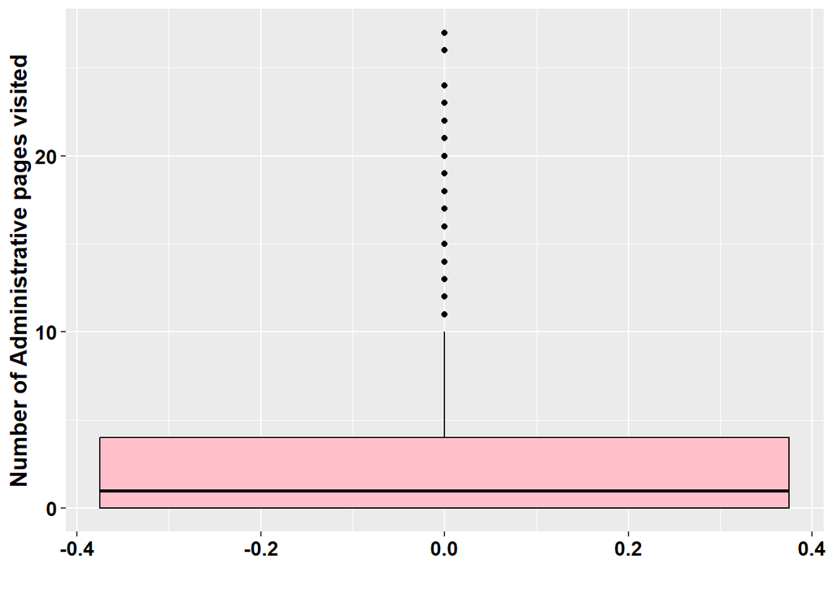

```r
ggplot(data, aes(y = Administrative)) +
  geom_boxplot(fill='pink', color='black') +
  labs(x = "", y = "Number of Administrative pages visited") +
  theme(axis.text.x = element_text(size=12, color="black", face="bold"),
        axis.text.y = element_text(size=12, color="black", face="bold"),
        axis.title = element_text(size=14, color="black", face="bold"),
        legend.position = "none",
        plot.title = element_text(size=16, color="black", face="bold"),
        plot.caption = element_text(size=10, color="black", hjust=0))
```

```r
cat("Summary")
```

```
## Summary
```

```r
summary(data$Administrative)
```

```
##    Min. 1st Qu.  Median    Mean 3rd Qu.    Max.
##   0.000   0.000   1.000   2.315   4.000  27.000
```

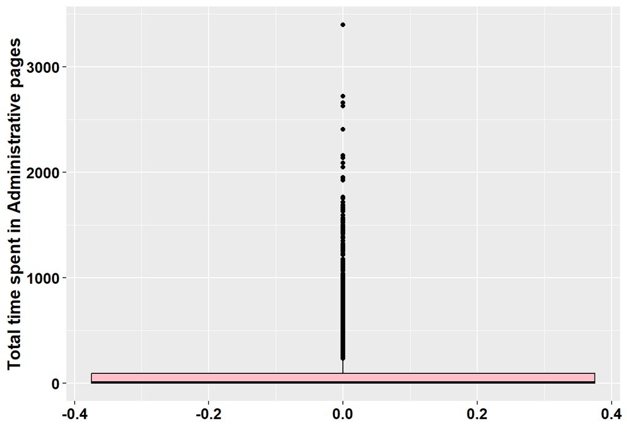

```r
ggplot(data, aes(y = Administrative_Duration)) +
  geom_boxplot(fill='pink', color='black') +
  labs(x = "", y = "Total time spent in Administrative pages")+
  theme(axis.text.x = element_text(size=12, color="black", face="bold"),
        axis.text.y = element_text(size=12, color="black", face="bold"),
        axis.title = element_text(size=14, color="black", face="bold"),
        legend.position = "none",
        plot.title = element_text(size=16, color="black", face="bold"),
        plot.caption = element_text(size=10, color="black", hjust=0))
```

```r
cat("Summary")
```

```
## Summary
```

```r
summary(data$Administrative_Duration)
```

```
##    Min. 1st Qu.  Median    Mean 3rd Qu.    Max.
##    0.00    0.00    7.50   80.82   93.26 3398.75
```

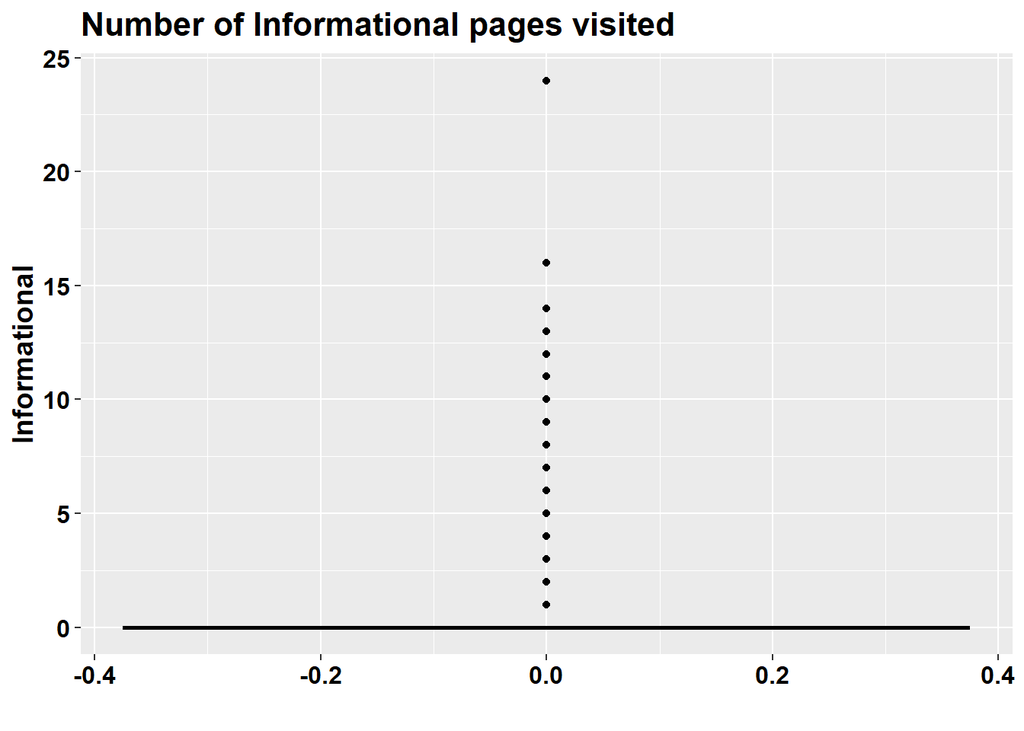

```r
ggplot(data, aes(y = Informational)) +
  geom_boxplot(fill='pink', color='black') +
  labs(x = "", y = "Informational",
       title = "Number of Informational pages visited") +
  theme(axis.text.x = element_text(size=12, color="black", face="bold"),
        axis.text.y = element_text(size=12, color="black", face="bold"),
        axis.title = element_text(size=14, color="black", face="bold"),
        legend.position = "none",
        plot.title = element_text(size=16, color="black", face="bold"),
        plot.caption = element_text(size=10, color="black", hjust=0))
```

```r
cat("Summary")
```

```
## Summary
```

```r
summary(data$Informational)
```

```
##    Min. 1st Qu.  Median    Mean 3rd Qu.    Max.
##  0.0000  0.0000  0.0000  0.5036  0.0000 24.0000
```

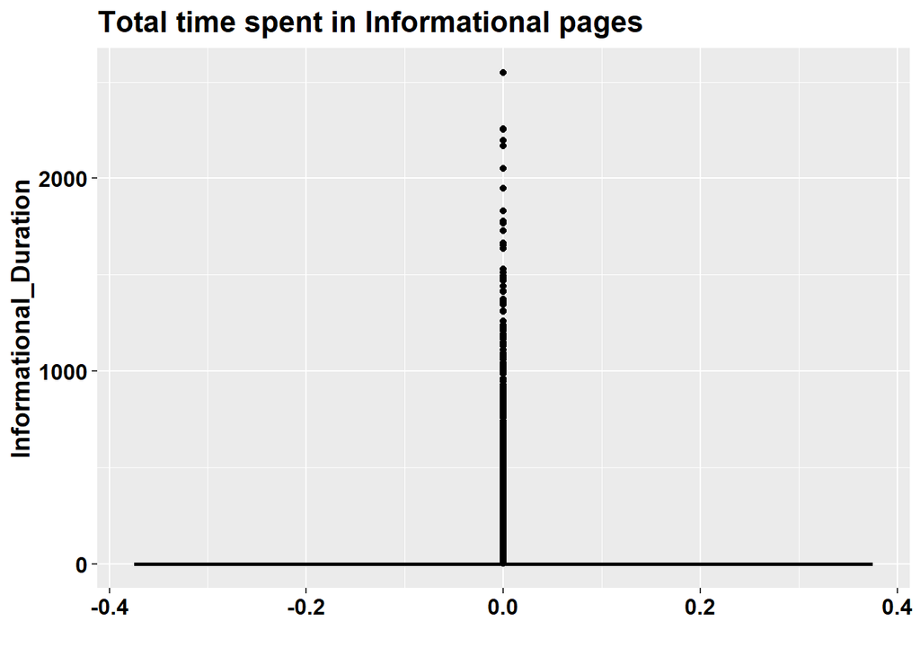

```r
ggplot(data, aes(y = Informational_Duration)) +
  geom_boxplot(fill='pink', color='black') +
  labs(x = "", y = "Informational_Duration",
       title = "Total time spent in Informational pages") +
  theme(axis.text.x = element_text(size=12, color="black", face="bold"),
        axis.text.y = element_text(size=12, color="black", face="bold"),
        axis.title = element_text(size=14, color="black", face="bold"),
        legend.position = "none",
        plot.title = element_text(size=16, color="black", face="bold"),
        plot.caption = element_text(size=10, color="black", hjust=0))
```

```r
cat("Summary")
```

```
## Summary
```

```r
summary(data$Informational_Duration)
```

```
##    Min. 1st Qu.  Median    Mean 3rd Qu.    Max.
##    0.00    0.00    0.00   34.47    0.00 2549.38
```

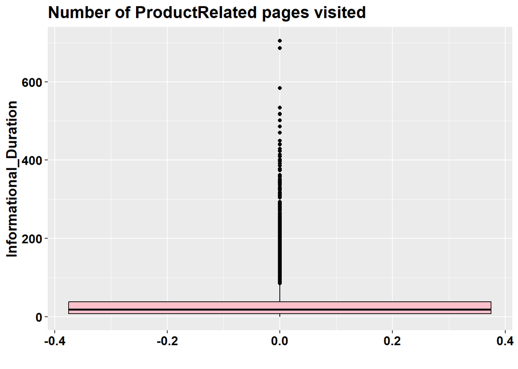

```r
ggplot(data, aes(y = ProductRelated)) +
  geom_boxplot(fill='pink', color='black') +
  labs(x = "", y = "Informational_Duration",
       title = "Number of ProductRelated pages visited") +
  theme(axis.text.x = element_text(size=12, color="black", face="bold"),
        axis.text.y = element_text(size=12, color="black", face="bold"),
        axis.title = element_text(size=14, color="black", face="bold"),
        legend.position = "none",
        plot.title = element_text(size=16, color="black", face="bold"),
        plot.caption = element_text(size=10, color="black", hjust=0))
```

```r
cat("Summary")
```

```
## Summary
```

```r
summary(data$ProductRelated)
```

```
##    Min. 1st Qu.  Median    Mean 3rd Qu.    Max.
##    0.00    7.00   18.00   31.73   38.00  705.00
```

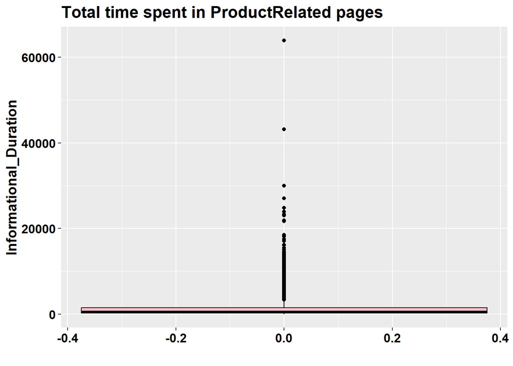

```r
ggplot(data, aes(y = ProductRelated_Duration)) +
  geom_boxplot(fill='pink', color='black') +
  labs(x = "", y = "Informational_Duration",
       title = "Total time spent in ProductRelated pages") +
  theme(axis.text.x = element_text(size=12, color="black", face="bold"),
        axis.text.y = element_text(size=12, color="black", face="bold"),
        axis.title = element_text(size=14, color="black", face="bold"),
        legend.position = "none",
        plot.title = element_text(size=16, color="black", face="bold"),
        plot.caption = element_text(size=10, color="black", hjust=0))
```

```r
cat("Summary")
```

```
## Summary
```

```r
summary(data$ProductRelated_Duration)
```

```
##    Min. 1st Qu.  Median    Mean 3rd Qu.    Max.
##     0.0   184.1   598.9  1194.8  1464.2 63973.5
```

```r
cat("\nMedian of Number of Administrative pages visited=",summary(data$Administrative)[3])
```

```
##
## Median of Number of Administrative pages visited= 1
```

```r
cat("\nMedian of Number of Informational pages visited=",summary(data$Informational)[3])
```

```
##
## Median of Number of Informational pages visited= 0
```

```r
cat("\nMedian of Number of ProductRelated pages visited=",summary(data$ProductRelated)[3],"\n")
```

```
##
## Median of Number of ProductRelated pages visited= 18
```

```r
cat("\nTotal time spent in Administrative pages=",summary(data$Administrative_Duration)[3])
```

```
##
## Total time spent in Administrative pages= 7.5
```

```r
cat("\nTotal time spent in InformationalRelated pages=",summary(data$Informational_Duration)[3])
```

```
##
## Total time spent in InformationalRelated pages= 0
```

```r
cat("\nTotal time spent in ProductRelated pages=",summary(data$ProductRelated_Duration)[3],"\n")
```

```
##
## Total time spent in ProductRelated pages= 598.9369
```

```r
cat("\nAnalysing number of pages vist of 3 different page categories it clearly says that customers are interested more in Product related pages rather than knowing information of the product in detail.\n")
```

```
##
## Analysing number of pages vist of 3 different page categories it clearly says that customers are interested more in Product related pages rather than knowing information of the product in detail.
```

```r
cat("\nAnalysing total time spent in 3 different page categories, it clearly says that customers spend most of the time in product related pages whereas they are not intrested in spending time in information related pages")
```

```
##
## Analysing total time spent in 3 different page categories, it clearly says that customers spend most of the time in product related pages whereas they are not intrested in spending time in information related pages
```

### Defining harmonic mean function

```r
hmean <- function(x) {
  n <- length(x)
  n / sum(1/x)
}
```

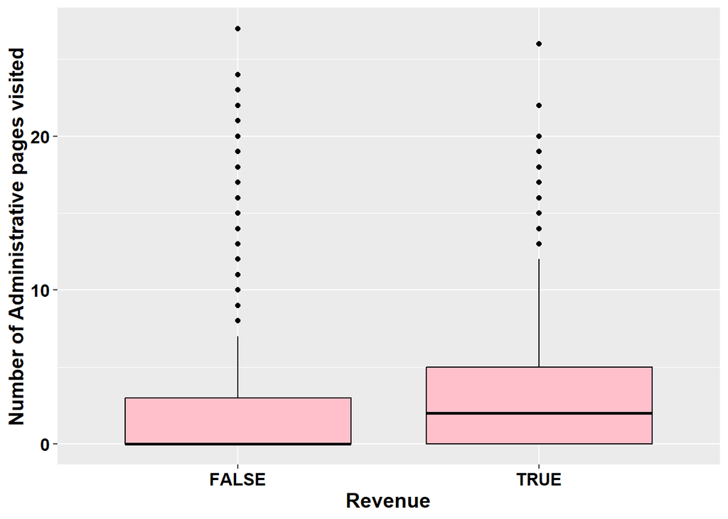

```r
ggplot(data, aes(x=Revenue, y=Administrative)) +
  geom_boxplot(fill='pink', color='black') +
  labs(x = "Revenue", y = "Number of Administrative pages visited") +
  theme(axis.text.x = element_text(size=12, color="black", face="bold"),
        axis.text.y = element_text(size=12, color="black", face="bold"),
        axis.title = element_text(size=14, color="black", face="bold"),
        legend.position = "none",
        plot.title = element_text(size=16, color="black", face="bold"),
        plot.caption = element_text(size=10, color="black", hjust=0))
```

```r
Administrative_true<-data %>%
  filter(Revenue == TRUE) %>%
  group_by(Administrative)

cat("\nMeadian number of adminstrative pages visted by a customer who end up buying is=",median(Administrative_true$Administrative))
```

```
##
## Meadian number of adminstrative pages visted by a customer who end up buying is= 2
```

```r
cat("\nHarmonic number of adminstrative pages visted by a customer who end up buying is=",hmean(Administrative_true$Administrative),"\n","\n")
```

```
##
## Harmonic number of adminstrative pages visted by a customer who end up buying is= 0
##
```

```r
print(summary(Administrative_true$Administrative))
```

```
##    Min. 1st Qu.  Median    Mean 3rd Qu.    Max.
##   0.000   0.000   2.000   3.394   5.000  26.000
```

```r
Administrative_false<-data %>%
  filter(Revenue == FALSE) %>%
  group_by(Administrative)


cat("\n\nMeadian number of adminstrative pages visted by a customer who did not end up buying is=",median(Administrative_false$Administrative))
```

```
##
##
## Meadian number of adminstrative pages visted by a customer who did not end up buying is= 0
```

```r
cat("\nHarmonic number of adminstrative pages visted by a customer who did not end up buying is=",hmean(Administrative_false$Administrative))
```

```
##
## Harmonic number of adminstrative pages visted by a customer who did not end up buying is= 0
```

```r
cat("\n","\n")
```

```r
print(summary(Administrative_false$Administrative))
```

```
##    Min. 1st Qu.  Median    Mean 3rd Qu.    Max.
##   0.000   0.000   0.000   2.118   3.000  27.000
```

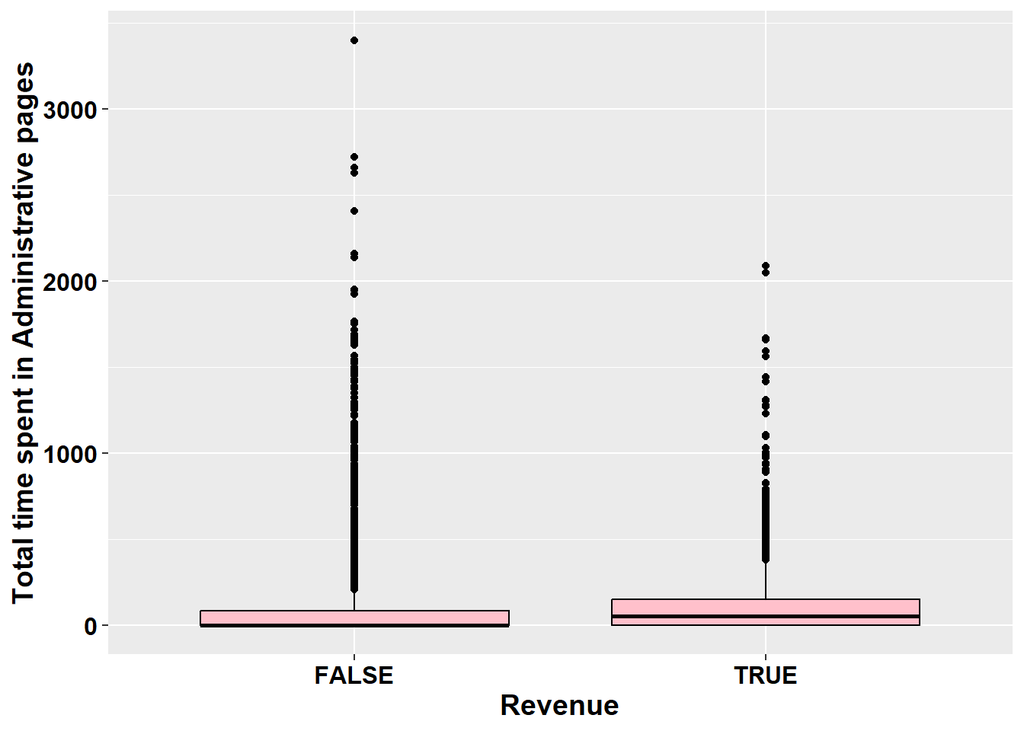

```r
ggplot(data, aes(x=Revenue, y=Administrative_Duration)) +
  geom_boxplot(fill='pink', color='black') +
  labs(x = "Revenue", y = "Total time spent in Administrative pages") +
  theme(axis.text.x = element_text(size=12, color="black", face="bold"),
        axis.text.y = element_text(size=12, color="black", face="bold"),
        axis.title = element_text(size=14, color="black", face="bold"),
        legend.position = "none",
        plot.title = element_text(size=16, color="black", face="bold"),
        plot.caption = element_text(size=10, color="black", hjust=0))
```

```r
Administrative_Duration_true<-data %>%
  filter(Revenue == TRUE) %>%
  group_by(Administrative_Duration)
cat("\nMeadian duration of time spent in adminstrative pages by a customer who end up buying is=",median(Administrative_Duration_true$Administrative_Duration))
```

```
##
## Meadian duration of time spent in adminstrative pages by a customer who end up buying is= 52.36667
```

```r
cat("\nHarmonic duration of time spent in adminstrative pages by a customer who end up buying is=",hmean(Administrative_Duration_true$Administrative_Duration),"\n","\n")
```

```
##
## Harmonic duration of time spent in adminstrative pages by a customer who end up buying is= 0
##
```

```r
print(summary(Administrative_Duration_true$Administrative_Duration))
```

```
##    Min. 1st Qu.  Median    Mean 3rd Qu.    Max.
##    0.00    0.00   52.37  119.48  151.08 2086.75
```

```r
Administrative_Duration_fasle<-data %>%
  filter(Revenue == FALSE) %>%
  group_by(Administrative_Duration)
cat("\n\nMeadian duration of time spent in adminstrative pages by a customer who did not end up buying is=",median(Administrative_Duration_fasle$Administrative_Duration))
```

```
##
##
## Meadian duration of time spent in adminstrative pages by a customer who did not end up buying is= 0
```

```r
cat("\nHarmonic duration of time spent in adminstrative pages by a customer who did not end up buying is=",hmean(Administrative_Duration_fasle$Administrative_Duration),"\n","\n")
```

```
##
## Harmonic duration of time spent in adminstrative pages by a customer who did not end up buying is= 0
##
```

```r
print(summary(Administrative_Duration_fasle$Administrative_Duration))
```

```
##    Min. 1st Qu.  Median    Mean 3rd Qu.    Max.
##    0.00    0.00    0.00   73.74   83.00 3398.75
```

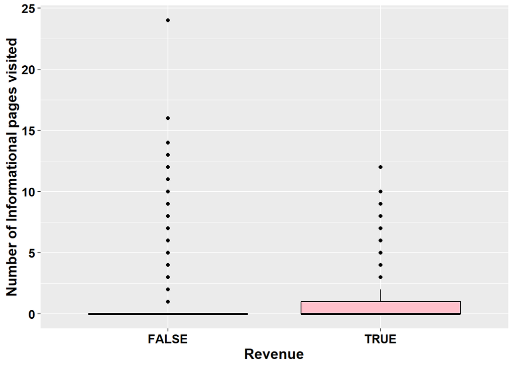

```r
ggplot(data, aes(x=Revenue, y=Informational)) +
  geom_boxplot(fill='pink', color='black') +
  labs(x = "Revenue", y = "Number of Informational pages visited") +
  theme(axis.text.x = element_text(size=12, color="black", face="bold"),
        axis.text.y = element_text(size=12, color="black", face="bold"),
        axis.title = element_text(size=14, color="black", face="bold"),
        legend.position = "none",
        plot.title = element_text(size=16, color="black", face="bold"),
        plot.caption = element_text(size=10, color="black", hjust=0))
```

```r
Informational_true<-data %>%
  filter(Revenue == TRUE) %>%
  group_by(Informational)

cat("\nMeadian number of Informational pages visted by a customer who end up buying is=",median(Informational_true$Informational))
```

```
##
## Meadian number of Informational pages visted by a customer who end up buying is= 0
```

```r
cat("\nHarmonic number of Informational pages visted by a customer who end up buying is=",hmean(Informational_true$Informational),"\n","\n")
```

```
##
## Harmonic number of Informational pages visted by a customer who end up buying is= 0
##
```

```r
print(summary(Informational_true$Informational))
```

```
##    Min. 1st Qu.  Median    Mean 3rd Qu.    Max.
##  0.0000  0.0000  0.0000  0.7862  1.0000 12.0000
```

```r
Informational_false<-data %>%
  filter(Revenue == FALSE) %>%
  group_by(Informational)
cat("\n\nMeadian number of Informational pages visted by a customer who did not end up buying is=",median(Informational_false$Informational))
```

```
##
##
## Meadian number of Informational pages visted by a customer who did not end up buying is= 0
```

```r
cat("\nHarmonic number of Informational pages visted by a customer who did not end up buying is=",hmean(Informational_false$Informational),"\n","\n")
```

```
##
## Harmonic number of Informational pages visted by a customer who did not end up buying is= 0
##
```

```r
print(summary(Informational_false$Informational))
```

```
##    Min. 1st Qu.  Median    Mean 3rd Qu.    Max.
##  0.0000  0.0000  0.0000  0.4518  0.0000 24.0000
```

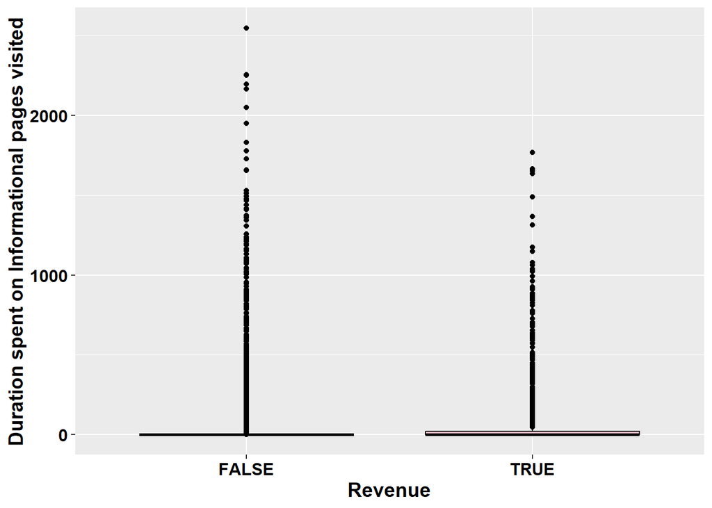

```r
ggplot(data, aes(x=Revenue, y=Informational_Duration)) +
  geom_boxplot(fill='pink', color='black') +
  labs(x = "Revenue", y = "Duration spent on Informational pages visited") +
  theme(axis.text.x = element_text(size=12, color="black", face="bold"),
        axis.text.y = element_text(size=12, color="black", face="bold"),
        axis.title = element_text(size=14, color="black", face="bold"),
        legend.position = "none",
        plot.title = element_text(size=16, color="black", face="bold"),
        plot.caption = element_text(size=10, color="black", hjust=0))
```

```r
Informational_Duration_true<-data %>%
  filter(Revenue == TRUE) %>%
  group_by(Informational_Duration)

cat("\nMeadian number of duration spent on Informational pages by a customer who end up buying is=",median(Informational_true$Informational))
```

```
##
## Meadian number of duration spent on Informational pages by a customer who end up buying is= 0
```

```r
cat("\nHarmonic number of duration spent on Informational pages by a customer who end up buying is=",hmean(Informational_true$Informational),"\n","\n")
```

```
##
## Harmonic number of duration spent on Informational pages by a customer who end up buying is= 0
##
```

```r
print(summary(Informational_Duration_true$Informational_Duration))
```

```
##    Min. 1st Qu.  Median    Mean 3rd Qu.    Max.
##    0.00    0.00    0.00   57.61   19.00 1767.67
```

```r
Informational_Duration_false<-data %>%
  filter(Revenue == FALSE) %>%
  group_by(Informational_Duration)
cat("\nMeadian number of duration spent on Informational pages by a customer who did not end up buying is=",median(Informational_Duration_false$Informational))
```

```
##
## Meadian number of duration spent on Informational pages by a customer who did not end up buying is= 0
```

```r
cat("\nHarmonic number of duration spent on Informational pages by a customer who did not end up buying is=",hmean(Informational_Duration_false$Informational),"\n","\n")
```

```
##
## Harmonic number of duration spent on Informational pages by a customer who did not end up buying is= 0
##
```

```r
print(summary(Informational_Duration_false$Informational_Duration))
```

```
##    Min. 1st Qu.  Median    Mean 3rd Qu.    Max.
##    0.00    0.00    0.00   30.24    0.00 2549.38
```

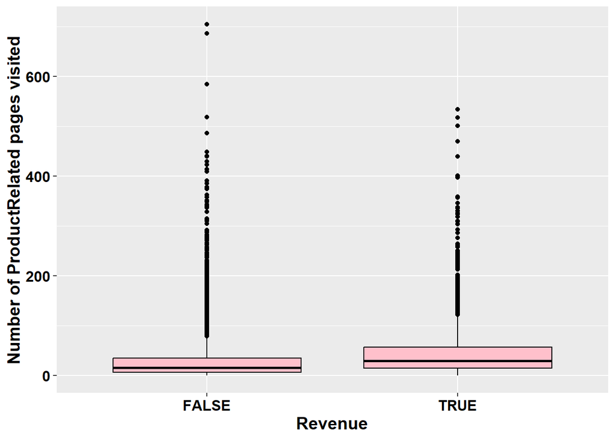

```r
ggplot(data, aes(x=Revenue, y=ProductRelated)) +
  geom_boxplot(fill='pink', color='black') +
  labs(x = "Revenue", y = "Number of ProductRelated pages visited") +
  theme(axis.text.x = element_text(size=12, color="black", face="bold"),
        axis.text.y = element_text(size=12, color="black", face="bold"),
        axis.title = element_text(size=14, color="black", face="bold"),
        legend.position = "none",
        plot.title = element_text(size=16, color="black", face="bold"),
        plot.caption = element_text(size=10, color="black", hjust=0))
```

```r
ProductRelated_true<-data %>%
  filter(Revenue == TRUE) %>%
  group_by(ProductRelated)

cat("\nMeadian number of ProductRelated pages visted by a customer who end up buying is=",median(ProductRelated_true$ProductRelated))
```

```
##
## Meadian number of ProductRelated pages visted by a customer who end up buying is= 29
```

```r
cat("\nHarmonic number of ProductRelated pages visted by a customer who end up buying is=",hmean(ProductRelated_true$ProductRelated),"\n","\n")
```

```
##
## Harmonic number of ProductRelated pages visted by a customer who end up buying is= 0
##
```

```r
print(summary(ProductRelated_true$ProductRelated))
```

```
##    Min. 1st Qu.  Median    Mean 3rd Qu.    Max.
##    0.00   15.00   29.00   48.21   57.00  534.00
```

```r
ProductRelated_false<-data %>%
  filter(Revenue == FALSE) %>%
  group_by(ProductRelated)
cat("\n\nMeadian number of ProductRelated pages visted by a customer who did not end up buying is=",median(ProductRelated_false$ProductRelated))
```

```
##
##
## Meadian number of ProductRelated pages visted by a customer who did not end up buying is= 16
```

```r
cat("\nHarmonic number of ProductRelated pages visted by a customer who did not end up buying is=",hmean(ProductRelated_false$ProductRelated),"\n","\n")
```

```
##
## Harmonic number of ProductRelated pages visted by a customer who did not end up buying is= 0
##
```

```r
print(summary(ProductRelated_false$ProductRelated))
```

```
##    Min. 1st Qu.  Median    Mean 3rd Qu.    Max.
##    0.00    6.00   16.00   28.71   35.00  705.00
```

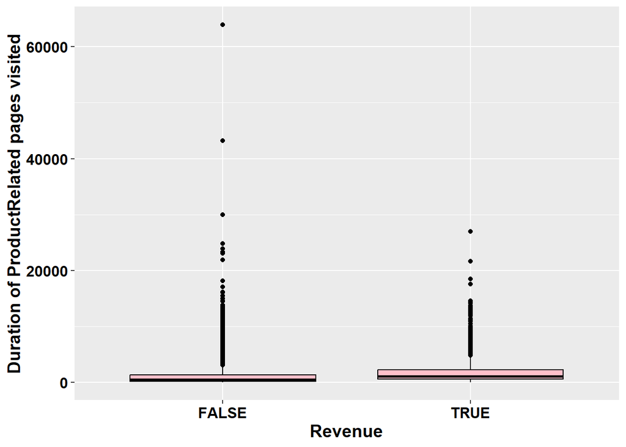

```r
ggplot(data, aes(x=Revenue, y=ProductRelated_Duration)) +
  geom_boxplot(fill='pink', color='black') +
  labs(x = "Revenue", y = "Duration of ProductRelated pages visited") +
  theme(axis.text.x = element_text(size=12, color="black", face="bold"),
        axis.text.y = element_text(size=12, color="black", face="bold"),
        axis.title = element_text(size=14, color="black", face="bold"),
        legend.position = "none",
        plot.title = element_text(size=16, color="black", face="bold"),
        plot.caption = element_text(size=10, color="black", hjust=0))
```

```r
ProductRelated_Duration_true<-data %>%
  filter(Revenue == TRUE) %>%
  group_by(ProductRelated_Duration)

cat("\nMeadian duration of ProductRelated pages visted by a customer who end up buying is=",median(ProductRelated_Duration_true$ProductRelated_Duration))
```

```
##
## Meadian duration of ProductRelated pages visted by a customer who end up buying is= 1109.906
```

```r
cat("\nHarmonic duration of ProductRelated pages visted by a customer who end up buying is=",hmean(ProductRelated_Duration_true$ProductRelated_Duration),"\n","\n")
```

```
##
## Harmonic duration of ProductRelated pages visted by a customer who end up buying is= 0
##
```

```r
print(summary(ProductRelated_Duration_true$ProductRelated_Duration))
```

```
##    Min. 1st Qu.  Median    Mean 3rd Qu.    Max.
##     0.0   541.9  1109.9  1876.2  2266.0 27009.9
```

```r
ProductRelated_Duration_false<-data %>%
  filter(Revenue == FALSE) %>%
  group_by(ProductRelated_Duration)

cat("\n\nMeadian duration of ProductRelated pages visted by a customer who did not end up buying is=",median(ProductRelated_Duration_false$ProductRelated_Duration))
```

```
##
##
## Meadian duration of ProductRelated pages visted by a customer who did not end up buying is= 510.19
```

```r
cat("\nHarmonic duration of ProductRelated pages visted by a customer who did not end up buying is=",hmean(ProductRelated_Duration_false$ProductRelated_Duration),"\n","\n")
```

```
##
## Harmonic duration of ProductRelated pages visted by a customer who did not end up buying is= 0
##
```

```r
print(summary(ProductRelated_Duration_false$ProductRelated_Duration))
```

```
##    Min. 1st Qu.  Median    Mean 3rd Qu.    Max.
##     0.0   151.0   510.2  1070.0  1331.8 63973.5
```